# EDA - Predicting Mental Health Outcomes from Music Listening Behaviour

#### Correlation Matrix (Mental Health + Behavior Features)

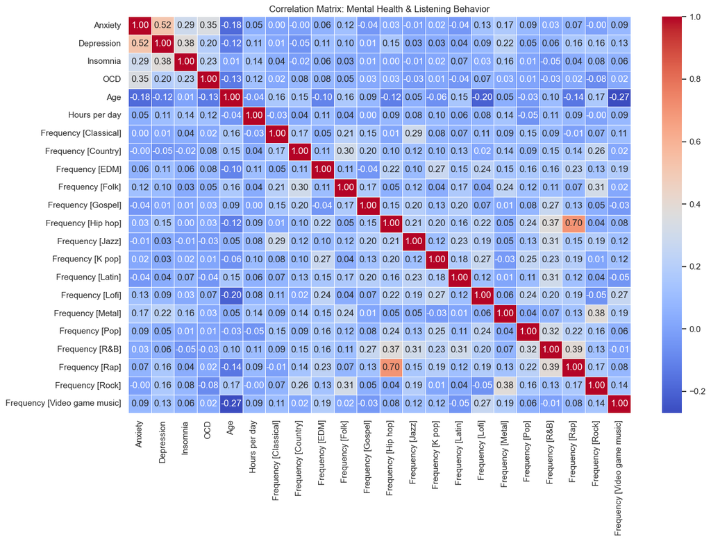

```python
# Defining genre frequency columns
genre_cols = [col for col in df.columns if col.startswith('Frequency')]

# Defining mapping if not applied yet
frequency_map = {
    'Never': 0,
    'Rarely': 1,
    'Sometimes': 2,
    'Very Often': 3
}

# Ensure mapping applied
if df[genre_cols].dtypes.iloc[0] == 'object':
    for col in genre_cols:
        df[col] = df[col].astype(str).str.strip().str.title().map(frequency_map)

# Selecting numeric features of interest
mh_features = ['Anxiety', 'Depression', 'Insomnia', 'OCD']
behavior_features = ['Age', 'Hours per day'] + genre_cols
selected_cols = mh_features + behavior_features

# Ensuring genre ratings are numeric
for col in genre_cols:
    df[col] = pd.to_numeric(df[col], errors='coerce')

# Correlation heatmap
plt.figure(figsize=(14, 10))
sns.heatmap(df[selected_cols].corr(), cmap='coolwarm', annot=True, fmt=".2f", linewidths=0.5)
plt.title('Correlation Matrix: Mental Health & Listening Behavior')
plt.tight_layout()
plt.savefig('../plots/12. Correlation_Matrix_Mental_Health_and_Listening_Behavior.png')
plt.show()
```

The correlation matrix shows depression and anxiety to be moderately correlated (0.52), as would also be predicted by the extensive literature on the comorbidity of these two mental health conditions. Other scores like insomnia and OCD likewise show small but significant positive correlations with anxiety and depression, suggesting that persons with one are somewhat more likely to report symptoms of the other ones as well.

#### Age vs Hours of Music Listening

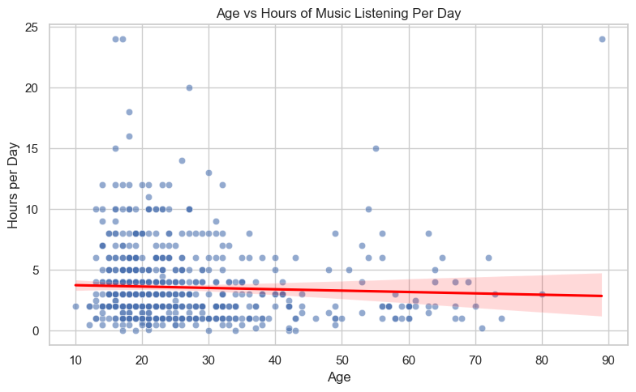

```python
plt.figure(figsize=(8, 5))
sns.scatterplot(data=df, x='Age', y='Hours per day', alpha=0.6)
sns.regplot(data=df, x='Age', y='Hours per day', scatter=False, color='red')
plt.title('Age vs Hours of Music Listening Per Day')
plt.xlabel('Age')
plt.ylabel('Hours per Day')
plt.tight_layout()
plt.savefig('../plots/13. Age_vs_Hours_of_Music_Listening_Per_Day.png')
plt.show()
```

#### Average Mental Health Scores by Favorite Genre

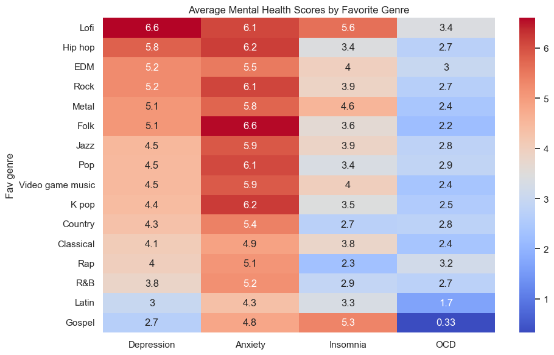

```python
avg_scores_by_genre = df.groupby('Fav genre')[['Depression', 'Anxiety', 'Insomnia', 'OCD']].mean().sort_values(by = 'Depression', ascending = False)
plt.figure(figsize = (10, 6))
sns.heatmap(avg_scores_by_genre, annot = True, cmap = 'coolwarm')
plt.title("Average Mental Health Scores by Favorite Genre")
plt.tight_layout()
plt.savefig("../plots/14. Average_Mental_Health_Scores_by_Favorite_Genre.png")
plt.show()
```